# Beech Marcenscence Project Analysis

Abbey, Andew, Bruce, Daniel, Marjorie, Morgaine, Rosy, Sylvie, Vincent, Carolyn

December 29, 2022

# 1 Set up

## 1.1 Liberies

```r
library(tidyverse)
library(glmmTMB)
library(performance)
library(sjPlot)
library(vegan)
library(ggpubr)
library(herbivar) # https://github.com/vsbpan/herbivar
#library(piecewiseSEM)
#library(DHARMa)
```

## 1.2 Brief note on image processing

This is what we have as the original scanned images (600 dpi).

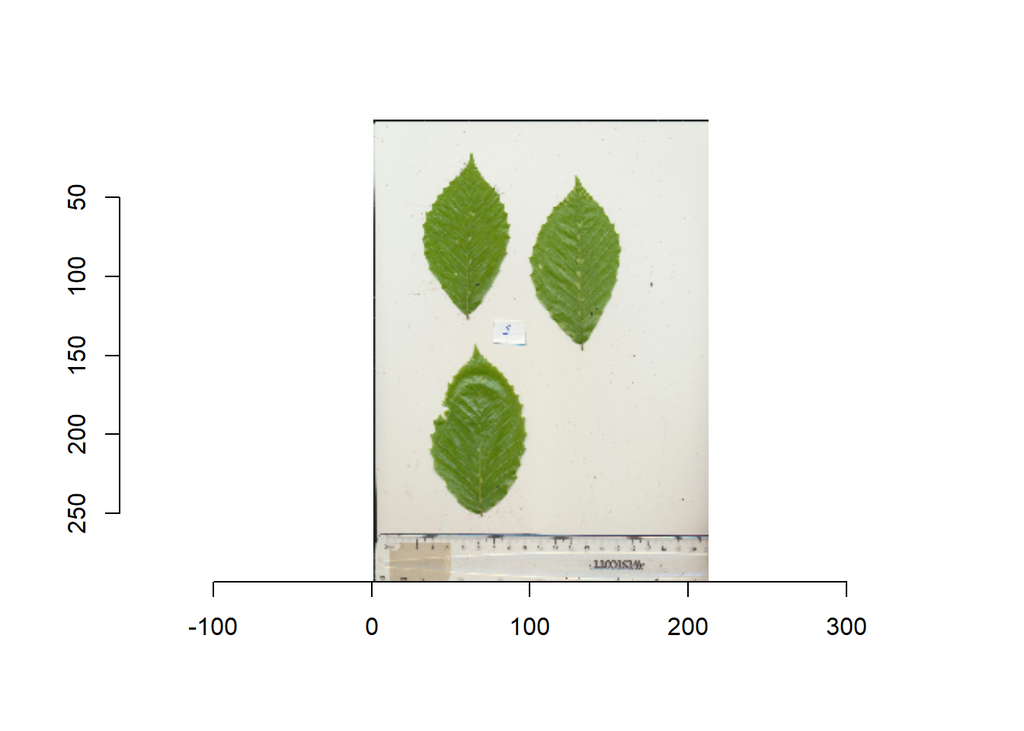

```r
img <- load.image("images/original_raw/marcescence_project_2022_May/tree1_20220517.jpeg") %>%
  thin(20) # reduce image resolution to enhance plotting speed.
plot(img)
```

For each image, the script `leaf_image_segmentation.R` cuts out the individual leaves as such:

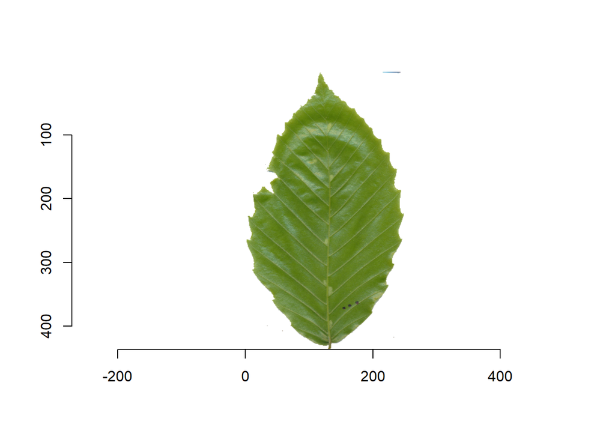

```r
img <- load.image("images/segmented_raw/2022_May_isolate/tree1_20220517_leaf3.png") %>%
  thin(5)
plot(img)
```

Then, we use paint to manually pick out the background, the intact leaf area, the missing leaf area, and the mite galls:

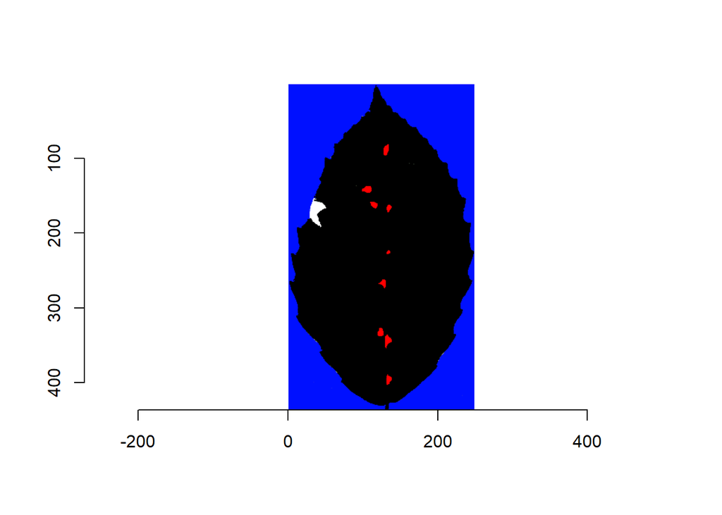

```r
img <- load.image("images/segmented_processed/2022_May_isolate/tree1_20220517_leaf3.png") %>%
  thin(5)
plot(img)
```

The script `read_painted_leaves.R` then reads the different marked regions of the processed images and outputs a .csv file. It’s basically counting pixels. Of note is that there is a detection limit of galls at 0.1% of the leaf area and chewing herbivory at 0.5% of the leaf area. The pipeline relies on the packages `pliman`, `imager`, and `herbivar`.

```r
citation("imager")
```

```
  Barthelme S (2022). _imager: Image Processing Library Based on
  'CImg'_. R package version 0.42.13,
  <https://CRAN.R-project.org/package=imager>.

A BibTeX entry for LaTeX users is

  @Manual{,
    title = {imager: Image Processing Library Based on 'CImg'},
    author = {Simon Barthelme},
    year = {2022},
    note = {R package version 0.42.13},
    url = {https://CRAN.R-project.org/package=imager},
  }
```

```r
citation("pliman")
```

```
  Olivoto T (2021). _pliman: Tools for Plant Image Analysis_. R package
  version 1.1.0, <https://CRAN.R-project.org/package=pliman>.

A BibTeX entry for LaTeX users is

  @Manual{,
    title = {pliman: Tools for Plant Image Analysis},
    author = {Tiago Olivoto},
    year = {2021},
    note = {R package version 1.1.0},
    url = {https://CRAN.R-project.org/package=pliman},
  }
```

```r
citation("herbivar")
```

```
  Pan V (2022). _herbivar: Quantitative Tools For Variance Explicit
  Ecology and Herbivory_. R package version 0.1.0.

A BibTeX entry for LaTeX users is

  @Manual{,
    title = {herbivar: Quantitative Tools For Variance Explicit Ecology and Herbivory},
    author = {Vincent Pan},
    year = {2022},
    note = {R package version 0.1.0},
  }
```

## 1.3 Cleaned data READ ME

*File: beech_marcescence_cleaned.csv*

**tree**: Unique tree identifier  
**leaf**: Unique leaf identifier  
**treatment**: Whether the tree had its leaves removed in the winter (“control” or “treatment”)  
**exp.round**: Survey session (1,2,3)  
**field.date**: Date of leaf collection  
**lab.date**: Date of mite examination (?)  
**field.obs**: Observer initials (not analyzed)  
**lab.mite.obs**: Observer initials (not analyzed)  
**dom**: count of domatia on the leaf  
**eggs**: count of mite eggs on the leaf  
**RS**: ? mite morphospecies count  
**LB**: ? mite morphospecies count  
**nymph**: ? mite nymphs count (multiple morphospecies)  
**OB**: ? mite morphospecies count  
**LL**: ? mite morphospecies count  
**LC**: ? mite morphospecies count  
**CLB**: ? mite morphospecies count  
**SP**: ? mite morphospecies count  
**MISC**: ? mite morphospecies count (multiple morphospecies)  
**BY**: ? mite morphospecies count  
**PR**: ? mite morphospecies count  
**B**: ? mite morphospecies count  
**eriophyid.pres**: visual assessment of the presence/absence of Eriophid galls (not analyzed)  
**fungal.obs**: Observer initials (not analyzed)  
**fungal.count**: Count of fungal bodies  
**fungal.notes**: Notes (not analyzed)  
**midrib.tape**: Not sure what this is (not analyzed)  
**leaf.tear**: Not sure what this is (not analyzed)  
**mite.notes**: Notes (not analyzed)  
**field.notes**: Notes (not analyzed)  
**gall_mm2**: Area of Eriophid galls in mm2 from leaf scan images  
**prop_herb**: Proportion of leaf with chewing damage from leaf scan images  
**leaf_area_mm2**: Area of leaf in mm2 from leaf scan images  
**longitude**: Longitude in degree decimals of the tree  
**latitude**: Latitude in degree decimals of the tree  
**elevation**: Elevation in meters of the tree

## 1.4 More data cleaning

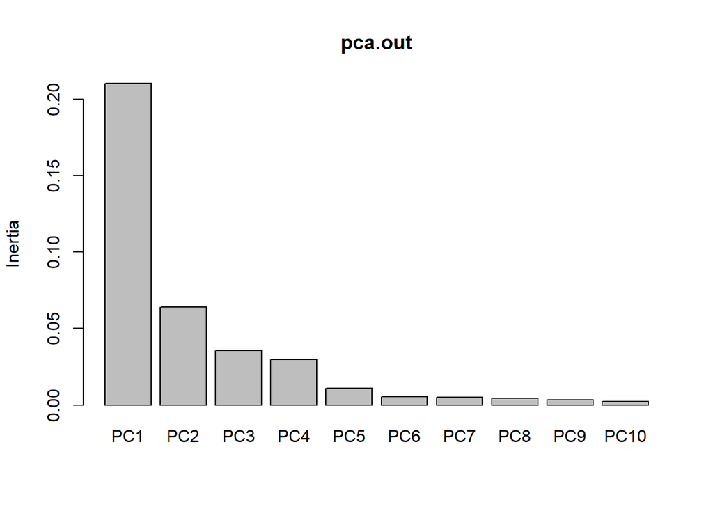

```r
d <- read_csv("cleaned_data/beech_marcescence_cleaned.csv") # Read data

# Change to factor for AR1
d$exp.round <- factor(d$exp.round)

d$total.good.mites <- with(d, RS + LB + OB + LL + B + LC + CLB + SP + MISC + BY + PR + nymph)

d$total.good.mites.adults <- d$total.good.mites - d$nymph

# Species considered in the composition analysis
species_col <- c("RS", "LB", "OB", "LL", "B", "LC", "CLB", "SP", "MISC", "BY", "PR")
community_mat <- d[species_col]

# Simple PCA, keeping track of the tree id
# Hellinger transform the community matrix
pca.out <- rda(hellinger_trans(community_mat) ~
                 Condition(tree),
               data = d)

screeplot(pca.out) # Looks like it is enough to grab the first two PCs
```

```r
d <- d %>%
  mutate(PC1 = scores(pca.out)$sites[,1],
         PC2 = scores(pca.out)$sites[,2],
         shannon.H = vegan::diversity(community_mat)) # Add them to the data as an index of community composition


d$dom_log <- log(d$dom)
d$leaf_area_mm2_log <- log(d$leaf_area_mm2)
d$herb_mm2 <- d$prop_herb * d$leaf_area_mm2
d$herb_mm2_log <- log(d$herb_mm2 + 1)
d$gall_mm2_log <- log(d$gall_mm2 + 1)
d$fungal.count_log <- log(d$fungal.count + 1)

# Add scaled predictors
d <- d %>% cbind(
  d %>%
  dplyr::select(PC1, PC2, dom_log, shannon.H,
                leaf_area_mm2_log, fungal.count,
                gall_mm2, herb_mm2, fungal.count_log,
                gall_mm2_log, herb_mm2_log) %>%
  mutate_all(function(x) as.numeric(scale(x))) %>%
  rename_all(.funs = function(x)paste0(x,".scale"))
)
```

# 2 Exploratory Analysis

## 2.1 Histograms

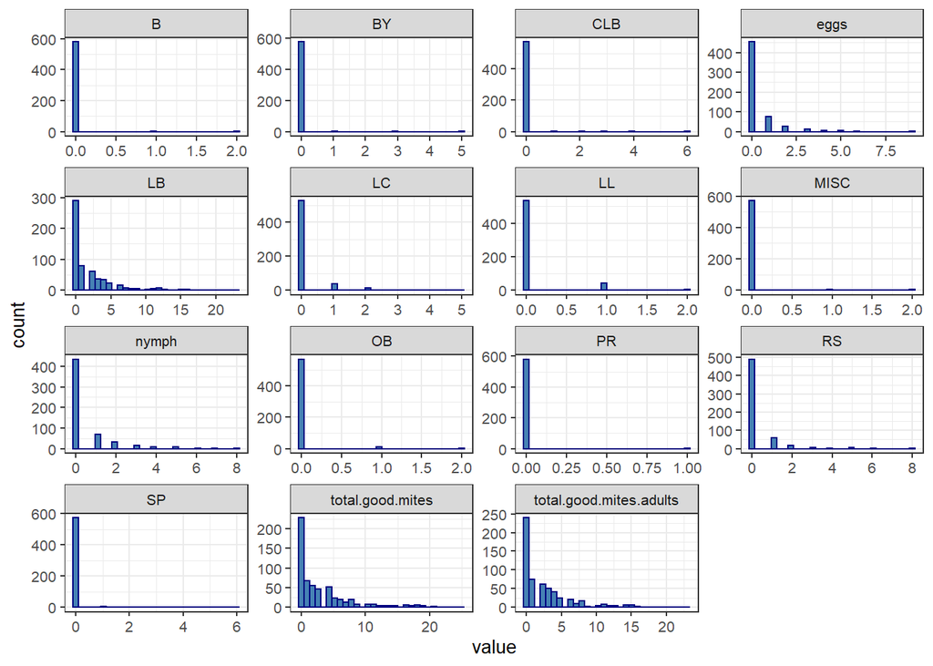

```r
explore_data_1 %>%
  ggplot(aes(x = value)) +
  geom_histogram(color = "navy", fill = "steelblue") +
  facet_wrap(~variable, scales = "free") +
  theme_bw(base_size = 10)
```

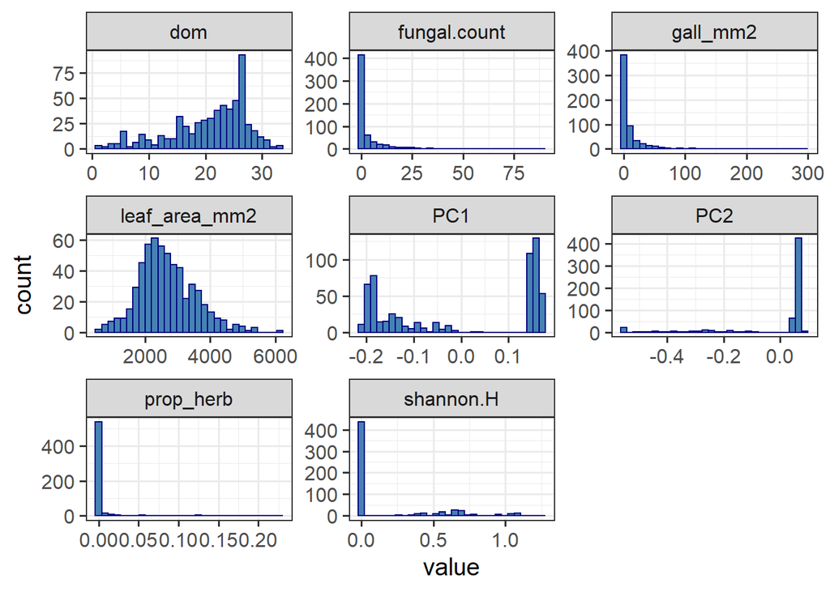

```r
explore_data_2 %>%
  ggplot(aes(x = value)) +
  geom_histogram(color = "navy", fill = "steelblue") +
  facet_wrap(~variable, scales = "free") +
  theme_bw(base_size = 15)
```

## 2.2 Variables by leaf position

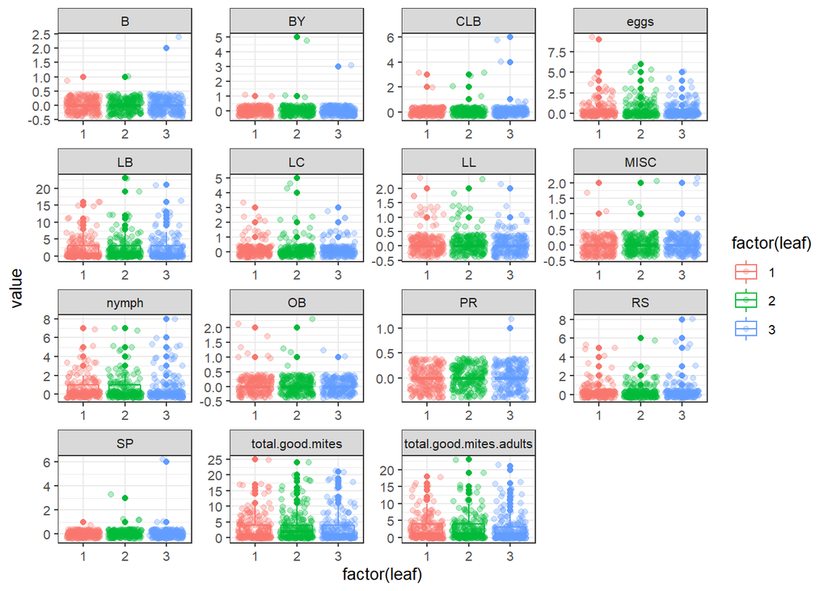

```r
explore_data_1 %>%
  ggplot(aes(x = factor(leaf),y = value, color = factor(leaf))) +
  geom_boxplot() +
  geom_point(position = "jitter", alpha = 0.3) +
  facet_wrap(~variable, scales = "free") +
  theme_bw(base_size = 10)
```

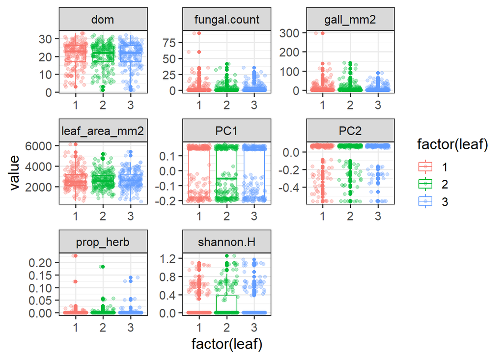

```r
explore_data_2 %>%
  ggplot(aes(x = factor(leaf),y = value, color = factor(leaf))) +
  geom_boxplot() +
  geom_point(position = "jitter", alpha = 0.3) +
  facet_wrap(~variable, scales = "free") +
  theme_bw(base_size = 15)
```

## 2.3 Variables by experiment round

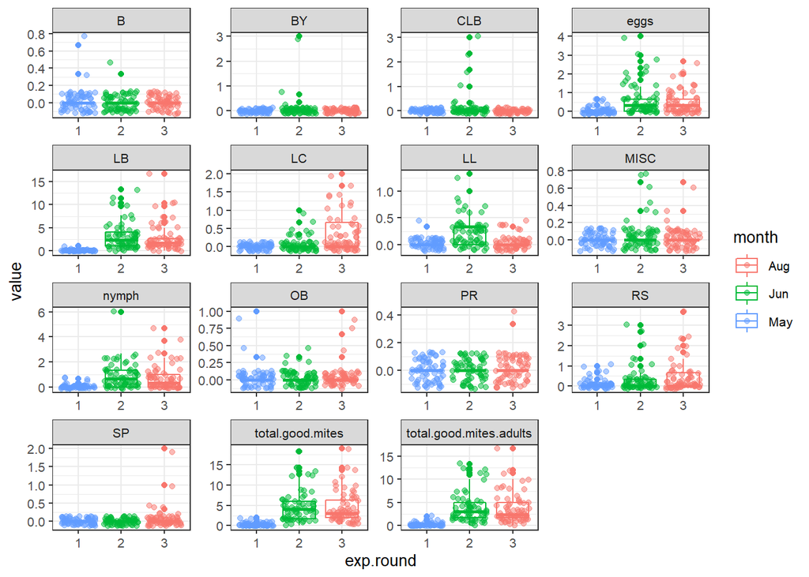

```r
explore_data_1tree_avg %>%
  ggplot(aes(x = exp.round, y = value, color = month)) +
  geom_boxplot() +
  geom_point(position = "jitter", alpha = 0.5) +
  facet_wrap(~variable, scales = "free") +
  theme_bw(base_size = 10)
```

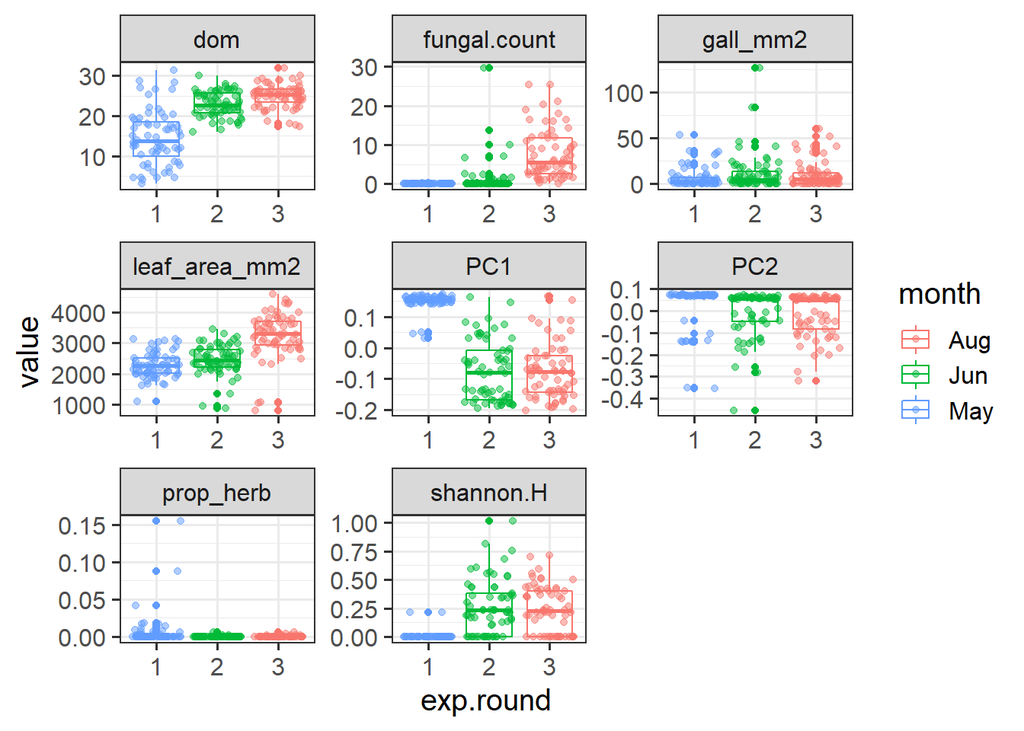

```r
explore_data_2tree_avg %>%
  ggplot(aes(x = exp.round, y = value, color = month)) +
  geom_boxplot() +
  geom_point(position = "jitter", alpha = 0.5) +
  facet_wrap(~variable, scales = "free") +
  theme_bw(base_size = 15)
```

## 2.4 Variables by treatment

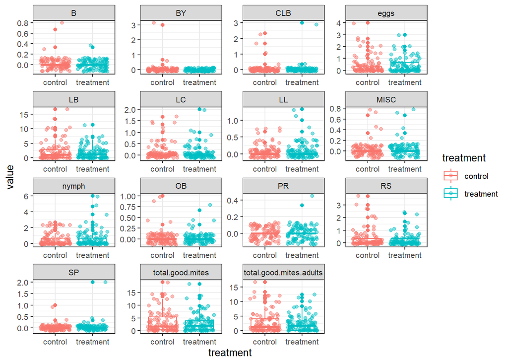

```r
explore_data_1tree_avg %>%
  ggplot(aes(x = treatment, y = value, color = treatment)) +
  geom_boxplot() +
  geom_point(position = "jitter", alpha = 0.5) +
  facet_wrap(~variable, scales = "free") +
  theme_bw(base_size = 10)
```

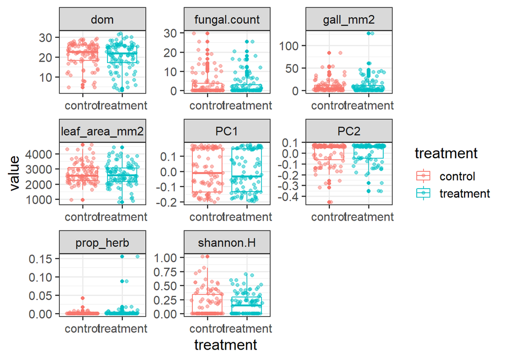

```r
explore_data_2tree_avg %>%
  ggplot(aes(x = treatment, y = value, color = treatment)) +
  geom_boxplot() +
  geom_point(position = "jitter", alpha = 0.5) +
  facet_wrap(~variable, scales = "free") +
  theme_bw(base_size = 15)
```

## 2.5 Variables by space

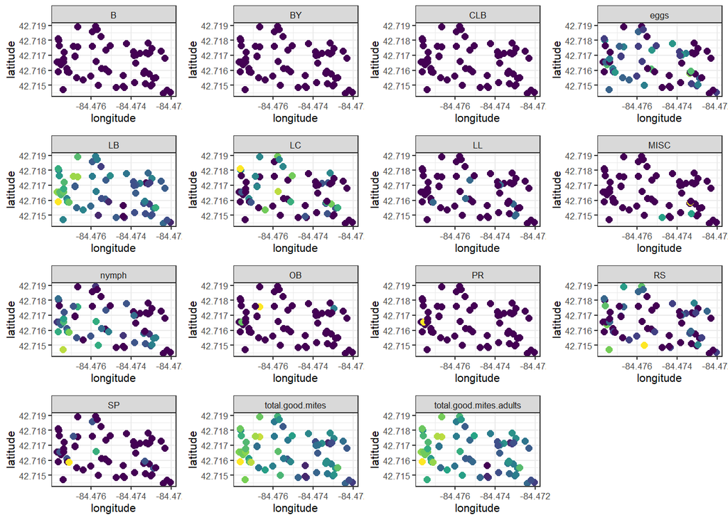

```r
explore_data_1tree_avg %>%
  mutate(valuelog = log(value + 1)) %>%
  ungroup() %>%
  group_split(variable) %>%
  map(
    ~ggplot(., aes(x = longitude, y = latitude, color = valuelog)) +
      geom_point(size = 2, show.legend = FALSE) +
      theme_bw(base_size = 8) +
      scale_color_viridis_c() +
      facet_grid(~variable, labeller = function(x) label_value(x, multi_line = FALSE))
  ) %>%
  ggpubr::ggarrange(plotlist = .)
```

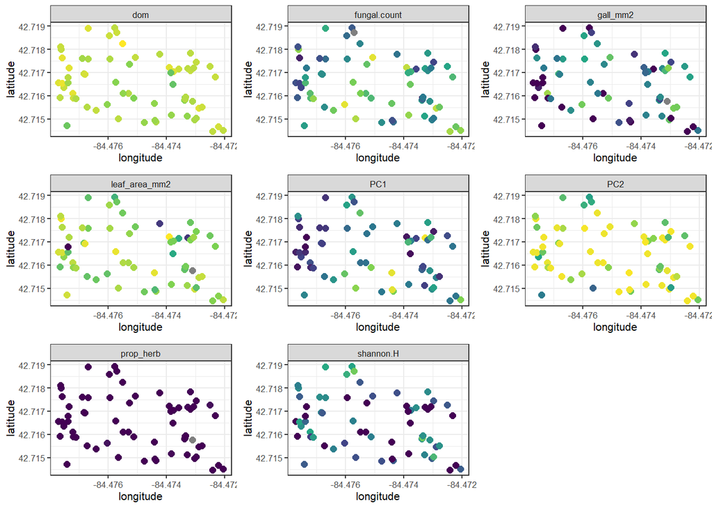

```r
explore_data_2tree_avg %>%
  mutate(valuelog = log(value + 1)) %>%
  ungroup() %>%
  group_split(variable) %>%
  map(
    ~ggplot(., aes(x = longitude, y = latitude, color = valuelog)) +
      geom_point(size = 2, show.legend = FALSE) +
      theme_bw(base_size = 8) +
      scale_color_viridis_c() +
      facet_grid(~variable, labeller = function(x) label_value(x, multi_line = FALSE))
  ) %>%
  ggpubr::ggarrange(plotlist = .)
```

## 2.6 Mite community PCA

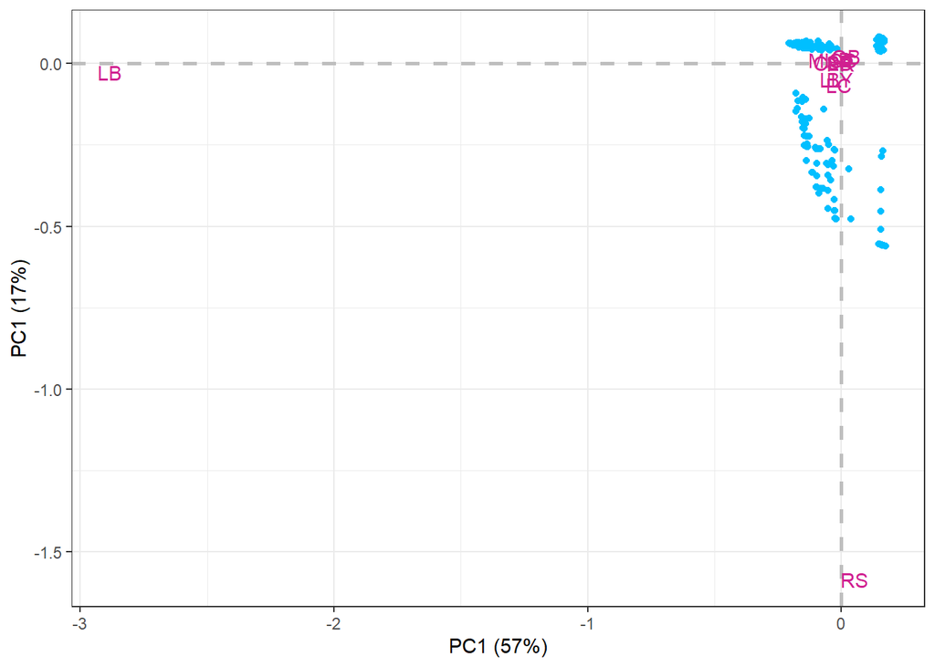

```r
#First 2 PCs
pca.out %>%
  get_biplot()
```

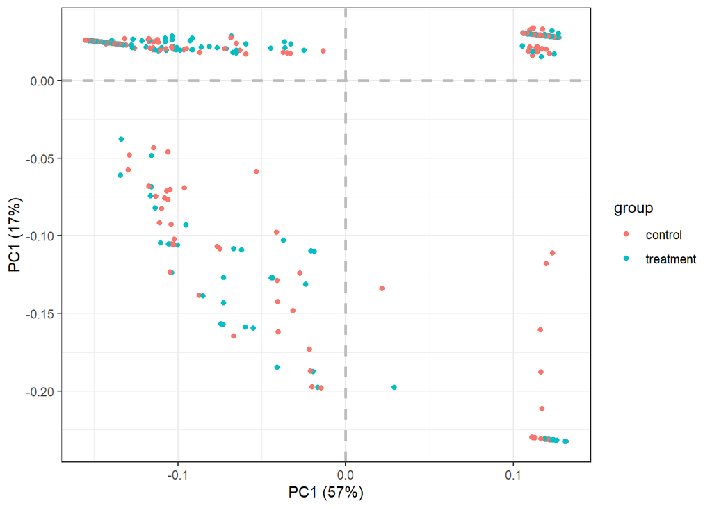

```r
# Visualize site scores
pca.out %>%
  get_biplot(group = d$treatment,
             display = c("sites"), scaling = "sites")
```

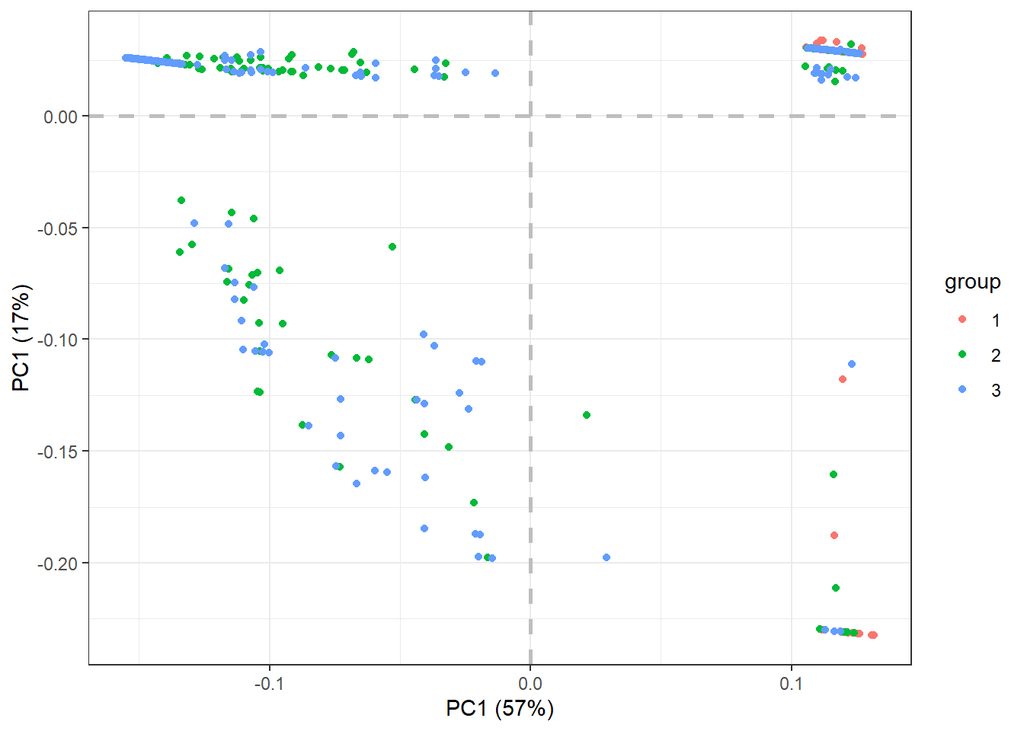

```r
pca.out %>%
  get_biplot(group = d$exp.round,
             display = c("sites"), scaling = "sites")
```

## 2.7 Missing values

First number is the number of complete records. Second number is the number of missing values. Each record is a leaf.

```r
#Missing values
d %>%
  dplyr::select(treatment, exp.round,
                all_of(interesting_variable_names1),
                all_of(interesting_variable_names2)) %>%
  group_by(exp.round,treatment) %>%
  summarise_all(function(x){
    paste0(sum(!is.na(x)),"-",sum(is.na(x)))
  }) %>%
  as.data.frame()
```

```
  exp.round treatment   RS   LB   OB   LL    B   LC  CLB   SP MISC   BY   PR
1         1   control 96-0 96-0 96-0 96-0 96-0 96-0 96-0 96-0 96-0 96-0 96-0
2         1 treatment 96-0 96-0 96-0 96-0 96-0 96-0 96-0 96-0 96-0 96-0 96-0
3         2   control 96-0 96-0 96-0 96-0 96-0 96-0 96-0 96-0 96-0 96-0 96-0
4         2 treatment 99-0 99-0 99-0 99-0 99-0 99-0 99-0 99-0 99-0 99-0 99-0
5         3   control 96-0 96-0 96-0 96-0 96-0 96-0 96-0 96-0 96-0 96-0 96-0
6         3 treatment 99-0 99-0 99-0 99-0 99-0 99-0 99-0 99-0 99-0 99-0 99-0
  nymph eggs total.good.mites total.good.mites.adults leaf_area_mm2 prop_herb
1  96-0 96-0             96-0                    96-0          96-0      96-0
2  96-0 96-0             96-0                    96-0          96-0      96-0
3  96-0 96-0             96-0                    96-0          96-0      96-0
4  99-0 99-0             99-0                    99-0          96-3      96-3
5  96-0 96-0             96-0                    96-0          93-3      93-3
6  99-0 99-0             99-0                    99-0          99-0      99-0
  gall_mm2 fungal.count  PC1  PC2  dom shannon.H
1     96-0         95-1 96-0 96-0 96-0      96-0
2     96-0         96-0 96-0 96-0 96-0      96-0
3     96-0         96-0 96-0 96-0 96-0      96-0
4     96-3         99-0 99-0 99-0 99-0      99-0
5     93-3         93-3 96-0 96-0 96-0      96-0
6     99-0         99-0 99-0 99-0 99-0      99-0
```

# 3 Main Analyses

## 3.1 A quick description of the analyses

My understanding is that we sort of have three main questions:

1. How does marcescence or domatia affect the mite bodyguards of beech trees?
2. How do mite bodyguards affect the pathogens and herbivores on beech trees?
3. Does marcescence or domatia affect the herbivory or pathogen risk of beech trees, possibly via mite bodyguards?

Because we are interested in a community of mite bodyguards, answering question (1) in its vague sense sort of include looking at three ecologically important features of any assemblage of species: the density, diversity, and community composition. The prior two features involve simple GLMMs, whereas the latter involves performing constrained ordination.

After analyzing the mite community, we move on to looking at important biological outcomes (gall area, chewing herbivory, fungal count) that may have responded to treatment or domatia count. In general, for each model, we include treatment and log(domatia count) along with other bare minimum model structures. We have both treatment and log(domatia count) in the same model mostly to reduce the number of models that we have to keep track of. log(domatia count) and treatment seem to not be that correlated so having both in the same model doesn’t affect the model coefficients that much.

The bare minimum model structures include the following:

1. random intercept of tree ID to keep track of each tree (each row is a leaf)
2. a fixed effect of experimental round (factor) to account for time dependent trends
3. a first order autoregressive component AR(1) that accounts for time dependence in the error structure.
4. I also included log(leaf_area_mm2) to account for the confounding relationships. For instance, when modeling fungal counts as a function of mite counts, we might expect this to hold:
   $$\text{mite count} \leftarrow \text{leaf area}
   \rightarrow \text{fungal count}$$
   or similarly
   $$\text{mite count} \leftarrow \text{leaf area}
   \rightarrow \text{gall area}$$

I did not include leaf position or space into the models because preliminary data explorations indicate that they are probably not important. In cases where there is quite a bit of spatial structure in the variable (e.g. mite counts), the results don’t change qualitatively (or the spatial version of the method, if it exits, is so very very annoying) so again, we’ll just ignore space. I also tested some interactions here and there and they don’t seem to be supported, so I have mostly showed you results of models without any interaction. Finally, because our missing leaf scans are probably missing completely at random, the missingness would not bias the estimates, so I don’t attempt to do any imputation.

After that we put everything together into a structural equation model where we test the specific structural hypotheses we have from question (2 and 3). It is important that we start with a reasonable meta-model structure and look at the size of the coefficients rather than performing model selection via AIC as has been advocated by some in the past. AIC is irrelevant to causal inference (Arif and MacNei 2022). I drew a DAG below that I think captures what is going out outside. Notice that we have to adjust for exp.round (time of year) and leaf area to get unbiased estimate of the effect of domatia count. The double arrows in there indicate correlated errors.

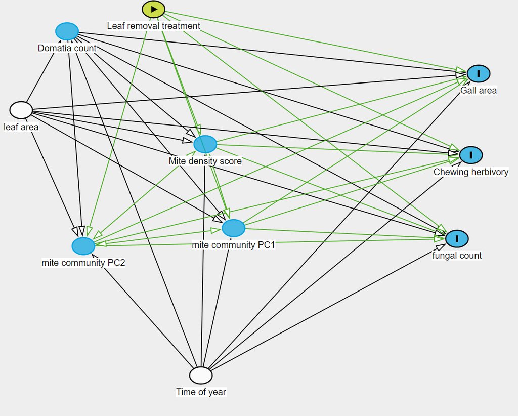

```r
knitr::include_graphics("graphs/a_priori_DAG.PNG")
```

Note that all continuous variables are Z-score transformed prior to fitting, so the regression coefficients are standardized.

## 3.2 Mite density

**key takeaways**: Only domatia density and time of year affected mite density. I tried fitting random slope models and zero-inflated models and the result is qualitatively the same.

### 3.2.1 Model

```r
# gather species
d.gathered <- d %>%
    gather(key = morphospecies, value = mite_count,all_of(species_col))

# Note that unlike other models, each row here is a unique morphospecies on a unique leaf during a unique time of year. We have morphospecies as a random intercept to keep track of each species.
den.m1 <- readRDS("RDS_files/den.m1.rds") # Takes too long to fit. Model code below
# den.m1 <- glmmTMB(
#   mite_count ~
#     treatment +
#     dom_log.scale +
#     leaf_area_mm2_log.scale +
#     exp.round +
#     (1 | morphospecies) +
#     (1 | tree)  +
#     ar1(0 + exp.round | tree),
#   family = nbinom2(link = "log"),
#   data = d.gathered
#   ); summary(den.m1)
summary(den.m1)
```

```
 Family: nbinom2  ( log )
Formula:
mite_count ~ treatment + dom_log.scale + leaf_area_mm2_log.scale +
    exp.round + (1 | morphospecies) + (1 | tree) + ar1(0 + exp.round |
    tree)
Data: d.gathered

     AIC      BIC   logLik deviance df.resid
  4012.2   4086.5  -1995.1   3990.2     6325

Random effects:

Conditional model:
 Groups        Name        Variance  Std.Dev.  Corr
 morphospecies (Intercept) 3.005e+00 1.7334580
 tree          (Intercept) 1.771e-08 0.0001331
 tree.1        exp.round1  4.310e-01 0.6564862 0.25 (ar1)
Number of obs: 6336, groups:  morphospecies, 11; tree, 65

Dispersion parameter for nbinom2 family (): 0.806

Conditional model:
                        Estimate Std. Error z value Pr(>|z|)
(Intercept)             -5.52870    0.58365  -9.473  < 2e-16 ***
treatmenttreatment      -0.13139    0.15355  -0.856  0.39220
dom_log.scale            0.49597    0.15430   3.214  0.00131 **
leaf_area_mm2_log.scale  0.04744    0.06403   0.741  0.45878
exp.round2               2.51579    0.26253   9.583  < 2e-16 ***
exp.round3               2.34062    0.28228   8.292  < 2e-16 ***
---
Signif. codes:  0 '***' 0.001 '**' 0.01 '*' 0.05 '.' 0.1 ' ' 1
```

### 3.2.2 Diagnostics

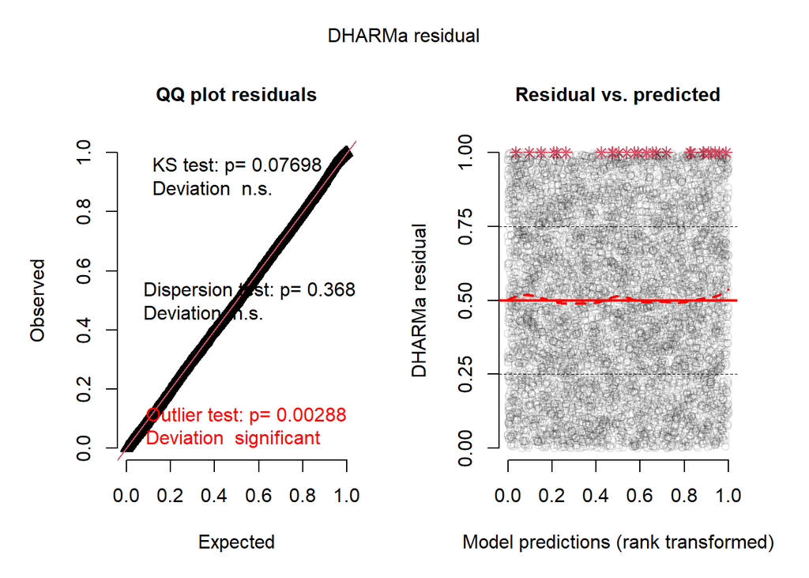

```r
# This is okay. dom_log in mixture models is significant for the bernoulli part of the model where the outliers don't matter.
DHARMa::simulateResiduals(den.m1) %>% plot()
```

```r
performance::check_collinearity(den.m1)
```

```
# Check for Multicollinearity

Low Correlation

                    Term  VIF   VIF 95% CI Increased SE Tolerance
               treatment 1.01 [1.00, 1.14]         1.00      0.99
           dom_log.scale 1.43 [1.39, 1.48]         1.20      0.70
 leaf_area_mm2_log.scale 1.19 [1.16, 1.23]         1.09      0.84
               exp.round 1.56 [1.51, 1.62]         1.25      0.64
 Tolerance 95% CI
     [0.88, 1.00]
     [0.68, 0.72]
     [0.81, 0.86]
     [0.62, 0.66]
```

### 3.2.3 Plot

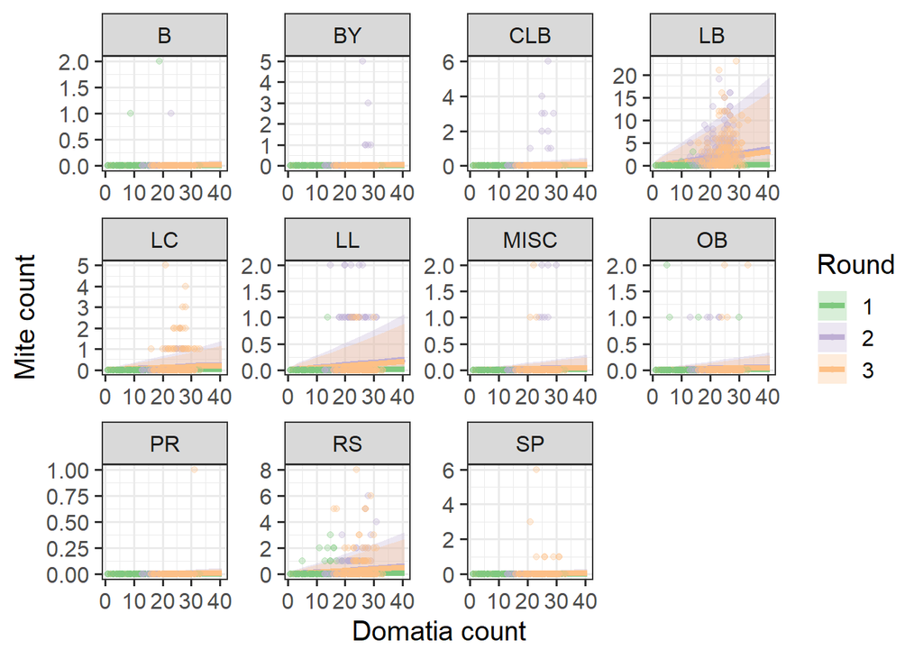

```r
#Tentative plot.
den.m1.re <- ggeffects::ggpredict(den.m1, terms = c("dom_log.scale","exp.round","morphospecies"), type = "random")


den.m1.re %>%
  as.data.frame() %>%
  ggplot(aes(x = exp(x * sd(d$dom_log) + mean(d$dom_log)), # Undo Z score transform then undo log
             y = predicted)) +
  geom_ribbon(aes(ymax = conf.high, ymin = conf.low, fill = factor(group)), alpha = 0.3) +
  geom_line(aes(color = factor(group)), size = 1.5) +
  facet_wrap(~facet, scales = "free") +
  geom_point(data = den.m1$frame %>%
               mutate(facet = morphospecies),
             aes(x = exp(dom_log.scale * sd(d$dom_log) + mean(d$dom_log)),
                 y = mite_count, color = exp.round), alpha = 0.3) +
  theme_bw(base_size = 15) +
  scale_fill_brewer(aesthetics = c("fill","color"), type = "qual") +
  labs(x = "Domatia count", y = "Mite count", color = "Round",fill="Round")
```

### 3.2.4 Misc stats

**random effect variance may be unreliable**

```r
r2(den.m1, tolerance = 10^-8)
```

```
# R2 for Mixed Models

  Conditional R2: 0.596
     Marginal R2: 0.258
```

## 3.3 Mite diversity

**key takeaways**: Only domatia density and time of year affected mite diversity.

### 3.3.1 Model

```r
div.m1 <- glmmTMB(
  shannon.H ~
    treatment +
    dom_log.scale +
    leaf_area_mm2_log.scale +
    exp.round +
    (1 | tree)  +
    ar1(0 + exp.round | tree),
  family = tweedie(link = "log"),
  data = d
); summary(div.m1)
```

```
 Family: tweedie  ( log )
Formula:
shannon.H ~ treatment + dom_log.scale + leaf_area_mm2_log.scale +
    exp.round + (1 | tree) + ar1(0 + exp.round | tree)
Data: d

     AIC      BIC   logLik deviance df.resid
   512.4    560.3   -245.2    490.4      565

Random effects:

Conditional model:
 Groups Name        Variance  Std.Dev.  Corr
 tree   (Intercept) 1.848e-02 0.1359262
 tree.1 exp.round1  1.145e-07 0.0003384 0.96 (ar1)
Number of obs: 576, groups:  tree, 65

Dispersion parameter for tweedie family (): 0.63

Conditional model:
                        Estimate Std. Error z value Pr(>|z|)
(Intercept)             -4.68034    0.62614  -7.475 7.72e-14 ***
treatmenttreatment       0.03690    0.16133   0.229  0.81909
dom_log.scale            0.69217    0.26041   2.658  0.00786 **
leaf_area_mm2_log.scale  0.02009    0.08366   0.240  0.81020
exp.round2               3.05441    0.64737   4.718 2.38e-06 ***
exp.round3               2.81627    0.66299   4.248 2.16e-05 ***
---
Signif. codes:  0 '***' 0.001 '**' 0.01 '*' 0.05 '.' 0.1 ' ' 1
```

### 3.3.2 Diagnostics

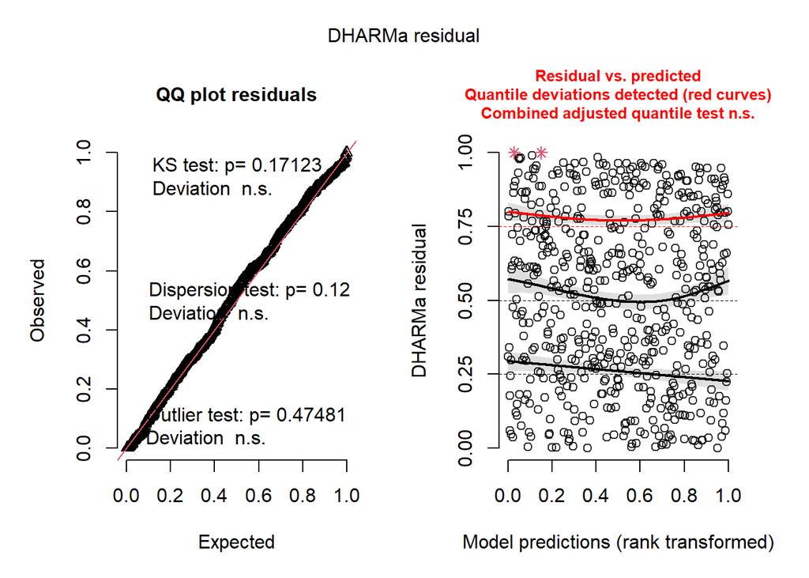

```r
DHARMa::simulateResiduals(div.m1) %>% plot()
```

```r
performance::check_collinearity(div.m1)
```

```
# Check for Multicollinearity

Low Correlation

                    Term  VIF    VIF 95% CI Increased SE Tolerance
               treatment 1.01 [1.00, 18.26]         1.01      0.99
           dom_log.scale 1.17 [1.09,  1.32]         1.08      0.86
 leaf_area_mm2_log.scale 1.21 [1.12,  1.36]         1.10      0.83
               exp.round 1.33 [1.22,  1.50]         1.15      0.75
 Tolerance 95% CI
     [0.05, 1.00]
     [0.76, 0.92]
     [0.74, 0.89]
     [0.67, 0.82]
```

### 3.3.3 Plot

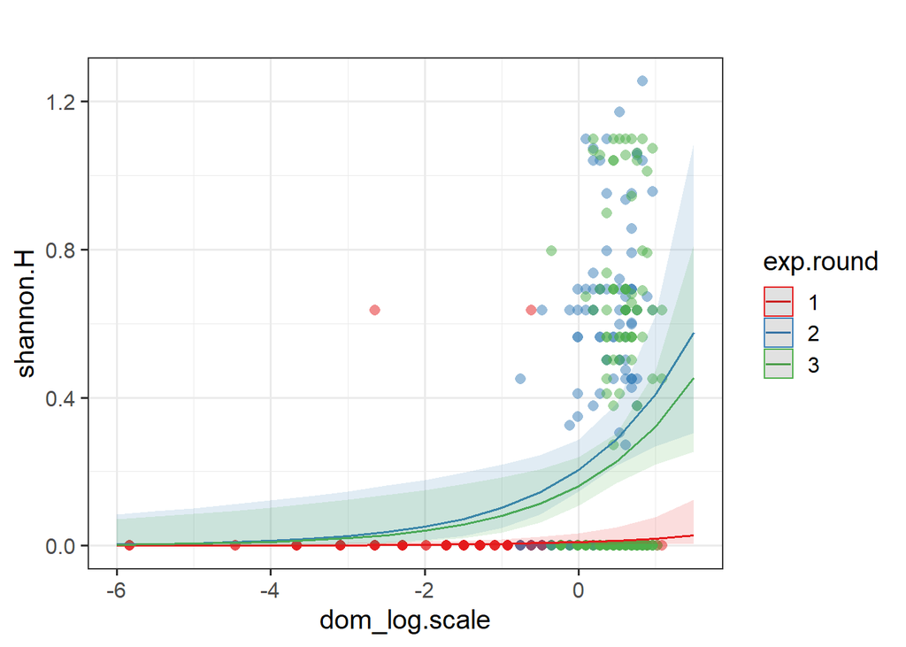

```r
plot_model(div.m1, type = "pred", terms = c("dom_log.scale","exp.round"), show.data = TRUE) +
  theme_bw(base_size = 15) +
  labs(title = "")
```

### 3.3.4 Misc stats

**random effect variance may be unreliable**

```r
r2(div.m1,tolerance = 10^-10)
```

```
# R2 for Mixed Models

  Conditional R2: 0.679
     Marginal R2: 0.676
```

## 3.4 Mite community composition

**key takeaways**: Only time of year strongly affected community composition.

### 3.4.1 Model

```r
d2 <- d %>%  # First get rid of NAs
  filter(!is.na(leaf_area_mm2))

cmp.m1 <- rda(hellinger_trans(d2[,species_col]) ~
      treatment +
      dom_log.scale +
      leaf_area_mm2_log.scale +
      exp.round +
      Condition(tree),
    data = d2)
cmp.m1
```

```
Call: rda(formula = hellinger_trans(d2[, species_col]) ~ treatment +
dom_log.scale + leaf_area_mm2_log.scale + exp.round + Condition(tree),
data = d2)

                Inertia Proportion Rank
Total         0.3703579  1.0000000
Conditional   0.0007972  0.0021525    1
Constrained   0.1001709  0.2704705    5
Unconstrained 0.2693898  0.7273770   11
Inertia is variance

Eigenvalues for constrained axes:
   RDA1    RDA2    RDA3    RDA4    RDA5
0.09581 0.00348 0.00082 0.00004 0.00002

Eigenvalues for unconstrained axes:
    PC1     PC2     PC3     PC4     PC5     PC6     PC7     PC8     PC9    PC10
0.12030 0.06168 0.03052 0.02578 0.01113 0.00516 0.00488 0.00428 0.00326 0.00217
   PC11
0.00021
```

```r
anova(cmp.m1, by = "mar", model = "reduced")
```

```
Permutation test for rda under reduced model
Marginal effects of terms
Permutation: free
Number of permutations: 999

Model: rda(formula = hellinger_trans(d2[, species_col]) ~ treatment + dom_log.scale + leaf_area_mm2_log.scale + exp.round + Condition(tree), data = d2)
                         Df Variance       F Pr(>F)
treatment                 1 0.000167  0.3519  0.824
dom_log.scale             1 0.000683  1.4429  0.219
leaf_area_mm2_log.scale   1 0.000782  1.6509  0.186
exp.round                 2 0.055240 58.3386  0.001 ***
Residual                569 0.269390
---
Signif. codes:  0 '***' 0.001 '**' 0.01 '*' 0.05 '.' 0.1 ' ' 1
```

```r
anova(cmp.m1, by = "axis")
```

```
Permutation test for rda under reduced model
Forward tests for axes
Permutation: free
Number of permutations: 999

Model: rda(formula = hellinger_trans(d2[, species_col]) ~ treatment + dom_log.scale + leaf_area_mm2_log.scale + exp.round + Condition(tree), data = d2)
          Df Variance        F Pr(>F)
RDA1       1 0.095811 202.3705  0.001 ***
RDA2       1 0.003479   7.3486  0.007 **
RDA3       1 0.000818   1.7269  0.549
RDA4       1 0.000038   0.0807  1.000
RDA5       1 0.000025   0.0523  1.000
Residual 569 0.269390
---
Signif. codes:  0 '***' 0.001 '**' 0.01 '*' 0.05 '.' 0.1 ' ' 1
```

### 3.4.2 Plot

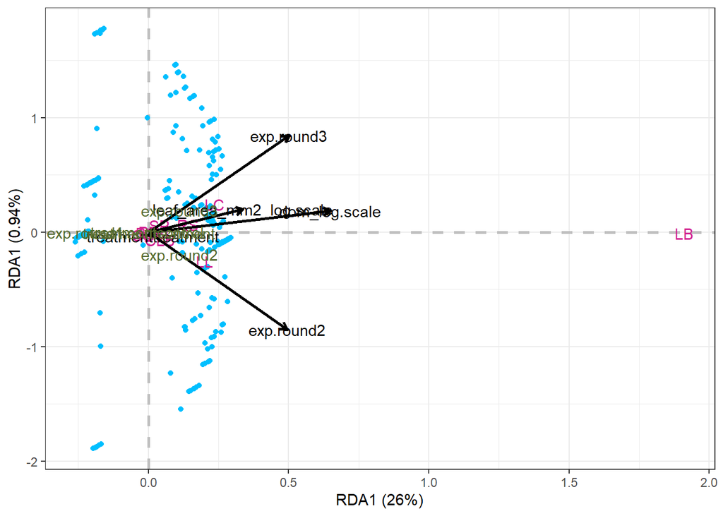

```r
get_biplot(cmp.m1)
```

## 3.5 Gall area

### 3.5.1 Model

```r
# Same result as with a zero-inflated Gamma model
ga.m1 <- glmmTMB(
  gall_mm2 ~
    treatment +
    dom_log.scale +
    leaf_area_mm2_log.scale +
    exp.round +
    (1|tree)  +
    ar1(0 + exp.round | tree),
  family = tweedie(link = "log"),
  data = d %>%
    mutate(dom_log.scale = scale(dom_log)),
  control=glmmTMBControl(optimizer=optim,
                         optArgs=list(method="BFGS"))
); summary(ga.m1)
```

```
 Family: tweedie  ( log )
Formula:
gall_mm2 ~ treatment + dom_log.scale + leaf_area_mm2_log.scale +
    exp.round + (1 | tree) + ar1(0 + exp.round | tree)
Data: d %>% mutate(dom_log.scale = scale(dom_log))

     AIC      BIC   logLik deviance df.resid
  2791.7   2839.6  -1384.8   2769.7      565

Random effects:

Conditional model:
 Groups Name        Variance Std.Dev. Corr
 tree   (Intercept) 1.74813  1.3222
 tree.1 exp.round1  0.05853  0.2419   -0.95 (ar1)
Number of obs: 576, groups:  tree, 65

Dispersion parameter for tweedie family (): 7.76

Conditional model:
                        Estimate Std. Error z value Pr(>|z|)
(Intercept)              1.32180    0.30410   4.347 1.38e-05 ***
treatmenttreatment      -0.29309    0.37472  -0.782   0.4341
dom_log.scale           -0.06473    0.11297  -0.573   0.5666
leaf_area_mm2_log.scale  0.18383    0.11153   1.648   0.0993 .
exp.round2               0.55122    0.23588   2.337   0.0194 *
exp.round3               0.33534    0.25494   1.315   0.1884
---
Signif. codes:  0 '***' 0.001 '**' 0.01 '*' 0.05 '.' 0.1 ' ' 1
```

### 3.5.2 Diagnostics

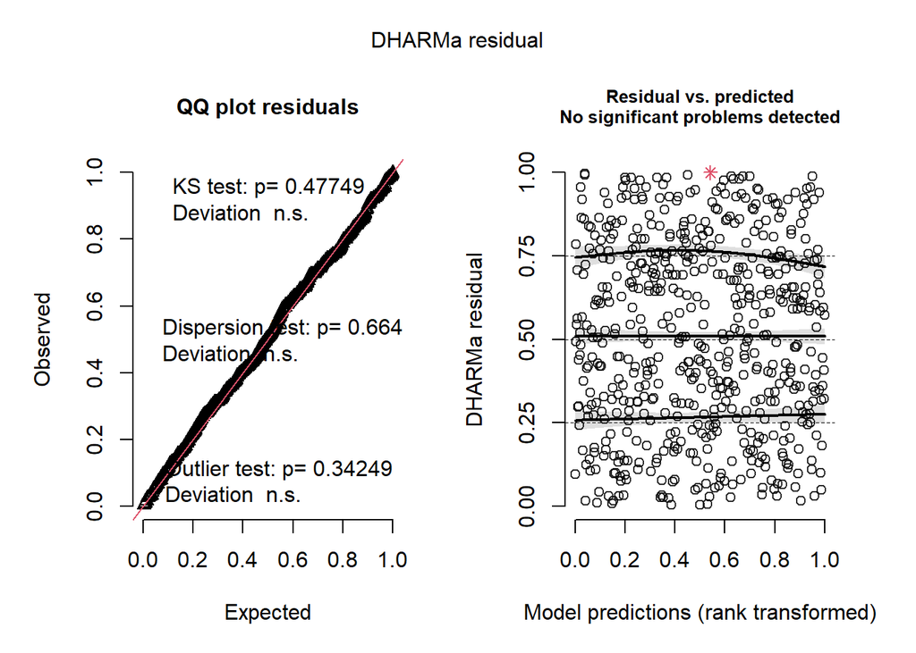

```r
DHARMa::simulateResiduals(ga.m1) %>% plot()
```

```r
check_collinearity(ga.m1)
```

```
# Check for Multicollinearity

Low Correlation

                    Term  VIF       VIF 95% CI Increased SE Tolerance
               treatment 1.00 [1.00, 1.27e+08]         1.00      1.00
           dom_log.scale 1.98 [1.77,     2.25]         1.41      0.50
 leaf_area_mm2_log.scale 1.47 [1.33,     1.65]         1.21      0.68
               exp.round 2.34 [2.08,     2.68]         1.53      0.43
 Tolerance 95% CI
     [0.00, 1.00]
     [0.44, 0.56]
     [0.61, 0.75]
     [0.37, 0.48]
```

### 3.5.3 Plot

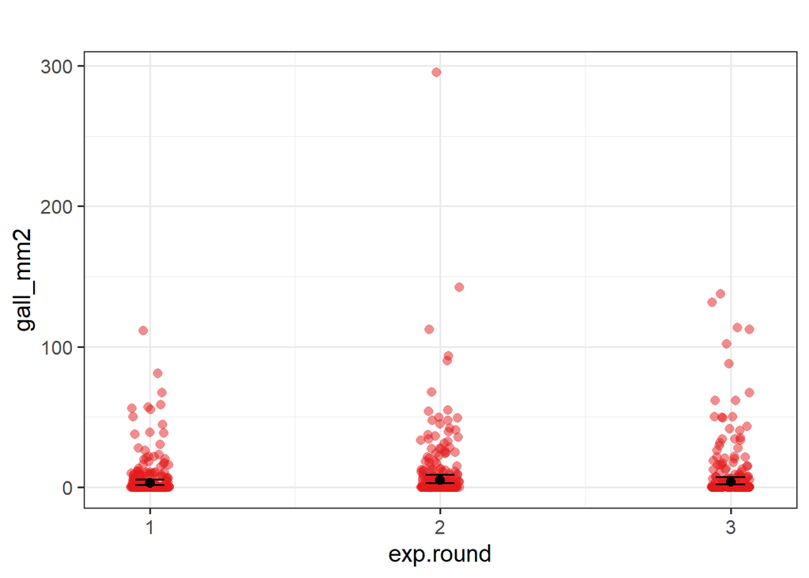

```r
plot_model(ga.m1, type = "pred", terms = c("exp.round"), show.data = TRUE, jitter = TRUE) +
  labs(title = "") +
  theme_bw(base_size = 15)
```

### 3.5.4 Misc stats

**random effect variance may be unreliable**

```r
r2(ga.m1)
```

```
# R2 for Mixed Models

  Conditional R2: 0.547
     Marginal R2: 0.031
```

## 3.6 Chewing herbivory

**key takeaways**: Treatment and domatia density increased herbivory, which is most severe in May. Larger leaves had lower herbivory, probably because they were able to toughen before peak herbivory occurred. The treatment result is in contrast with the chewing herbivory result of Karban (2008).

### 3.6.1 Model

```r
# Same result as with a zero-inflated Gamma model
herb.m1 <- glmmTMB(
  herb_mm2 ~
    treatment +
    dom_log.scale +
    leaf_area_mm2_log.scale +
    exp.round +
    (1|tree)  +
    ar1(0 + exp.round | tree),
  family = tweedie(link = "log"),
  data = d
); summary(herb.m1)
```

```
 Family: tweedie  ( log )
Formula:
herb_mm2 ~ treatment + dom_log.scale + leaf_area_mm2_log.scale +
    exp.round + (1 | tree) + ar1(0 + exp.round | tree)
Data: d

     AIC      BIC   logLik deviance df.resid
   595.4    643.3   -286.7    573.4      565

Random effects:

Conditional model:
 Groups Name        Variance  Std.Dev.  Corr
 tree   (Intercept) 7.905e-07 0.0008891
 tree.1 exp.round1  3.929e+00 1.9822276 -0.26 (ar1)
Number of obs: 576, groups:  tree, 65

Dispersion parameter for tweedie family (): 28.1

Conditional model:
                        Estimate Std. Error z value Pr(>|z|)
(Intercept)             -0.03448    0.81190  -0.042  0.96612
treatmenttreatment       1.36826    0.62260   2.198  0.02797 *
dom_log.scale            0.64213    0.32404   1.982  0.04752 *
leaf_area_mm2_log.scale -0.51331    0.24429  -2.101  0.03562 *
exp.round2              -3.78389    0.96673  -3.914 9.07e-05 ***
exp.round3              -2.48282    0.77665  -3.197  0.00139 **
---
Signif. codes:  0 '***' 0.001 '**' 0.01 '*' 0.05 '.' 0.1 ' ' 1
```

### 3.6.2 Diagnostics

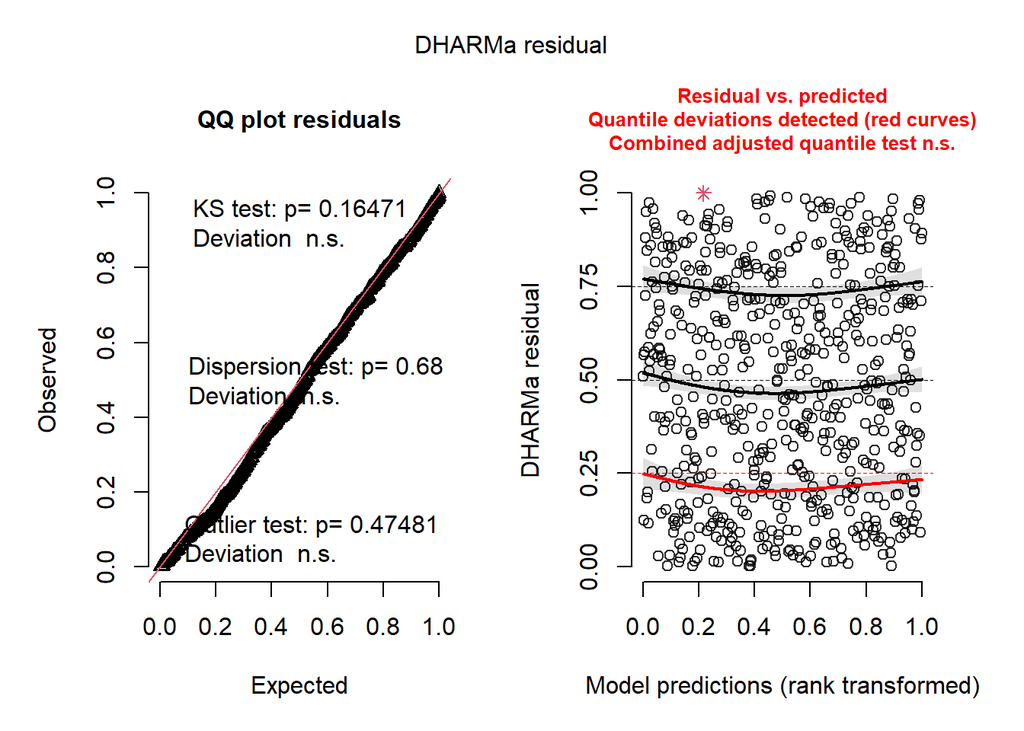

```r
# Not too shabby
DHARMa::simulateResiduals(herb.m1) %>% plot()
```

```r
check_collinearity(herb.m1)
```

```
# Check for Multicollinearity

Low Correlation

                    Term  VIF   VIF 95% CI Increased SE Tolerance
               treatment 1.05 [1.01, 1.31]         1.02      0.96
           dom_log.scale 1.37 [1.25, 1.54]         1.17      0.73
 leaf_area_mm2_log.scale 1.10 [1.04, 1.26]         1.05      0.91
               exp.round 1.38 [1.26, 1.55]         1.18      0.72
 Tolerance 95% CI
     [0.76, 0.99]
     [0.65, 0.80]
     [0.79, 0.96]
     [0.64, 0.79]
```